# Изучение рынка заведений общественного питания Москвы

### Цели и задачи проекта

**Цель:** проанализировать рынок общественного питания в Москве, чтобы помочь инвесторам выбрать оптимальный формат и место для нового заведения.

**Задачи:**

1. Изучить структуру рынка общепита Москвы
2. Проанализировать уровень конкуренции.
3. Оценить характеристики заведений.
4. Исследовать ценовой сегмент заведений.
5. Сформулировать рекомендации инвесторам.

### Описание данных

Для анализа доступны данные сервисов Яндекс Карты и Яндекс Бизнес на лето 2022 года. Данные состоят из двух датасетов:

- `rest_info.csv` — информация о заведениях общественного питания:
  - `name` — название заведения;
  - `address` — адрес заведения;
  - `district` — административный район, в котором находится заведение;
  - `category` — категория заведения (например `кафе`, `пиццерия` или `кофейня`);
  - `hours` — информация о днях и часах работы;
  - `rating` — рейтинг заведения по оценкам пользователей в Яндекс Картах (высшая оценка — 5.0);
  - `chain` — число, выраженное `0` или `1`, которое показывает, является ли заведение сетевым (для маленьких сетей могут встречаться ошибки):
    - `0` — заведение не является сетевым;
    - `1` — заведение является сетевым.
  - `seats` — количество посадочных мест.
- `rest_price.csv` — информацию о среднем чеке в заведениях общепита:
  - `price` — категория цен в заведении, например «средние», «ниже среднего», «выше среднего» и так далее;
  - `avg_bill` — строка, которая хранит среднюю стоимость заказа в виде диапазона, например:
    - `Средний счёт: 1000–1500 ₽`;
    - `Цена чашки капучино: 130–220 ₽`;
    - `Цена бокала пива: 400–600 ₽` и так далее;
  - `middle_avg_bill` — число с оценкой среднего чека, которое указано только для значений из столбца avg_bill, начинающихся с подстроки `Средний счёт`:
    - Если в строке указан ценовой диапазон из двух значений, в столбец войдёт медиана этих двух значений.
    - Если в строке указано одно число — цена без диапазона, то в столбец войдёт это число.
    - Если значения нет или оно не начинается с подстроки «Средний счёт», то в столбец ничего не войдёт.
  - `middle_coffee_cup` — число с оценкой одной чашки капучино, которое указано только для значений из столбца `avg_bill`, начинающихся с подстроки `Цена одной чашки капучино`:
    - Если в строке указан ценовой диапазон из двух значений, в столбец войдёт медиана этих двух значений.
    - Если в строке указано одно число — цена без диапазона, то в столбец войдёт это число.
    - Если значения нет или оно не начинается с подстроки `Цена одной чашки капучино`, то в столбец ничего не войдёт.

### Содержимое проекта

- 1 Загрузка данных и знакомство с ними
  - 1.1 Знакомство с данными
  - 1.2 Подготовка единого датафрейма
- 2 Предобработка данных
  - 2.1 Типы данных
  - 2.2 Наличие пропусков в данных
  - 2.3 Явные и неявные дубликаты в данных
  - 2.4 Промежуточный вывод
- 3 Исследовательский анализ данных
  - 3.1 Категории заведений
  - 3.2 Распределение заведений по районам
  - 3.3 Сетевые и несетвые заведения
  - 3.4 Количество посадочных мест
  - 3.5 Рейтинг заведений
  - 3.6 Корреляции рейтинга заведения с разными данными
  - 3.7 Топ-15 популярных сетей в Москве
  - 3.8 Средний чек
  - 3.9 Промежуточный вывод
- 4 Итоговый вывод и рекомендации
  - 4.1 Общий обзор проделанной работы
  - 4.2 Главные выводы
  - 4.3 Рекомендации на основе анализа данных

## 1 Загрузка данных и знакомство с ними

### 1.1 Знакомство с данными

- Начнём с загрузки библиотек и датасетов `/datasets/rest_info.csv` и `/datasets/rest_price.csv`. Будем использовать pandas и библиотеки визуализации данных matplotlib и seaborn, а также phik_matrix для построения матрицы корреляции. Данные датасетов сохраним в двух переменных: `rest_info_df` и `rest_price_df`.

```python
# Импортируем библиотеки
import pandas as pd

# Загружаем библиотеки для визуализации данных
import matplotlib.pyplot as plt
import seaborn as sns

# Загружаем библиотеку для расчёта коэффициента корреляции phi_k
!pip install phik
from phik import phik_matrix
```

```python
# Выгружаем данные в переменные rest_info_df и rest_price_df
rest_info_df = pd.read_csv('https://code.s3.yandex.net/datasets/rest_info.csv')
rest_price_df = pd.read_csv('https://code.s3.yandex.net/datasets/rest_price.csv')
```

- Познакомимся с данными датасетов `/datasets/rest_info.csv` и `/datasets/rest_price.csv` — выведем первые строки методом `head()`, а информацию о датафрейме методом `info()`:

```python
# Выводим первые строки датафрейма rest_info_df на экран
rest_info_df.head()
```

|  | id | name | category | address | district | hours | rating | chain | seats |
| --- | --- | --- | --- | --- | --- | --- | --- | --- | --- |
| 0 | 0c3e3439a8c64ea5bf6ecd6ca6ae19f0 | WoWфли | кафе | Москва, улица Дыбенко, 7/1 | Северный административный округ | ежедневно, 10:00–22:00 | 5.0 | 0 | NaN |
| 1 | 045780ada3474c57a2112e505d74b633 | Четыре комнаты | ресторан | Москва, улица Дыбенко, 36, корп. 1 | Северный административный округ | ежедневно, 10:00–22:00 | 4.5 | 0 | 4.0 |
| 2 | 1070b6b59144425896c65889347fcff6 | Хазри | кафе | Москва, Клязьминская улица, 15 | Северный административный округ | пн-чт 11:00–02:00; пт,сб 11:00–05:00; вс 11:00... | 4.6 | 0 | 45.0 |
| 3 | 03ac7cd772104f65b58b349dc59f03ee | Dormouse Coffee Shop | кофейня | Москва, улица Маршала Федоренко, 12 | Северный административный округ | ежедневно, 09:00–22:00 | 5.0 | 0 | NaN |
| 4 | a163aada139c4c7f87b0b1c0b466a50f | Иль Марко | пиццерия | Москва, Правобережная улица, 1Б | Северный административный округ | ежедневно, 10:00–22:00 | 5.0 | 1 | 148.0 |

```python
# Выводим информацию о датафрейме rest_info_df
rest_info_df.info()
```

```
<class 'pandas.core.frame.DataFrame'>
RangeIndex: 8406 entries, 0 to 8405
Data columns (total 9 columns):
 #   Column    Non-Null Count  Dtype
---  ------    --------------  -----
 0   id        8406 non-null   object
 1   name      8406 non-null   object
 2   category  8406 non-null   object
 3   address   8406 non-null   object
 4   district  8406 non-null   object
 5   hours     7870 non-null   object
 6   rating    8406 non-null   float64
 7   chain     8406 non-null   int64
 8   seats     4795 non-null   float64
dtypes: float64(2), int64(1), object(6)
memory usage: 591.2+ KB
```

Датасет `/datasets/rest_info.csv` содержит 9 столбцов и 8406 строк, в которых представлена информация о заведениях общественного питания Москвы. Два столбца содержат пропуски: `hours`, `seats`.

После первичного анализа данных можно сделать следующие выводы:

- Данные в столбцах `id`, `name`, `address`, `hours` содержат текстовую информацию и корректно представлены типом `object`.
- Категориальные данные в столбцах `category` и `district` представлены типом `object`. Однако целесообразно привести их к типу `category`, что улучшит читаемость и ускорит дальнейшую обработку.
- Рейтинг заведения хранится в `rating` и преставлен вещественным типом `float64`, размерность которого можно оптимизировать до `float32`.
- Данные в столбце `chain` хранятся в `int64` и содержит значения 1 или 0. Можно преобразовать в `int8` для экономии памяти.
- Данные `seats` хранятся в `float64` - значения являются количественными, но из-за пропусков представлен как `float`. После обработки пропусков может быть преобразован в `Int` с пониженной разрядностью.
- Судя по первому знакомству с данными, значения в столбцах соответствуют своему описанию.
- Теперь познакомимся с данными датасета rest_price_df.

```python
# Выводим первые строки датафрейма rest_price_df на экран
rest_price_df.head()
```

|  | id | price | avg_bill | middle_avg_bill | middle_coffee_cup |
| --- | --- | --- | --- | --- | --- |
| 0 | 045780ada3474c57a2112e505d74b633 | выше среднего | Средний счёт:1500–1600 ₽ | 1550.0 | NaN |
| 1 | 1070b6b59144425896c65889347fcff6 | средние | Средний счёт:от 1000 ₽ | 1000.0 | NaN |
| 2 | 03ac7cd772104f65b58b349dc59f03ee | NaN | Цена чашки капучино:155–185 ₽ | NaN | 170.0 |
| 3 | a163aada139c4c7f87b0b1c0b466a50f | средние | Средний счёт:400–600 ₽ | 500.0 | NaN |
| 4 | 8a343546b24e4a499ad96eb7d0797a8a | средние | NaN | NaN | NaN |

```python
# Выводим информацию о датафрейме rest_price_df
rest_price_df.info()
```

```
<class 'pandas.core.frame.DataFrame'>
RangeIndex: 4058 entries, 0 to 4057
Data columns (total 5 columns):
 #   Column             Non-Null Count  Dtype
---  ------             --------------  -----
 0   id                 4058 non-null   object
 1   price              3315 non-null   object
 2   avg_bill           3816 non-null   object
 3   middle_avg_bill    3149 non-null   float64
 4   middle_coffee_cup  535 non-null    float64
dtypes: float64(2), object(3)
memory usage: 158.6+ KB
```

Датасет `/datasets/rest_price.csv` содержит 5 столбцов и 4058 строк, описывающих ценовую информацию о заведениях общественного питания Москвы. В столбцах `price`, `avg_bill`, `middle_avg_bill`, `middle_coffee_cup` присутствуют пропущенные значения в различной степени.

- Данные в столбцах `id`, `avg_bill` содержат текстовую информацию и корректно представлены типом `object`. Поле `id` является уникальным идентификатором заведения и будет использоваться как ключ при объединении с основным датасетом.
- Категориальные данные в столбце `price` представлены типом `object`. Приведем их к типу `category` для оптимизации хранения и анализа.
- Числовые столбцы `middle_avg_bill` и `middle_coffee_cup` хранят целочисленную информацию об оценки среднего чека и с ценой одной чашки капучино. Т.к. содержат пропуски - представлены типом `float64`. После обработки пропусков приведем их к типу `Int` c пониженной разрядностью, который позволяет хранить целые числа вместе с пропущенными значениями.
- Значения в столбцах соответствуют своему описанию.
- Столбец `avg_bill` содержит текстовые диапазоны цен, из которых уже извлечены числовые значения в `middle_avg_bill` и `middle_coffee_cup`. Оригинальный текст можно оставить только в справочных целях или удалить после объединения.

### 1.2 Подготовка единого датафрейма

- Соединим данные датасета `/datasets/rest_info.csv` с `/datasets/rest_price.csv` по полю `id`, используя значение параметра `how` = `left`. Это позволит оставить полные данные по заведениям общественного питания.

```python
# Соединяем данные в единый датафрейм df
df = rest_info_df.merge(rest_price_df, on='id', how='left')
```

```python
# Выводим информацию о датафрейме
df.info()
```

```
<class 'pandas.core.frame.DataFrame'>
Int64Index: 8406 entries, 0 to 8405
Data columns (total 13 columns):
 #   Column             Non-Null Count  Dtype
---  ------             --------------  -----
 0   id                 8406 non-null   object
 1   name               8406 non-null   object
 2   category           8406 non-null   object
 3   address            8406 non-null   object
 4   district           8406 non-null   object
 5   hours              7870 non-null   object
 6   rating             8406 non-null   float64
 7   chain              8406 non-null   int64
 8   seats              4795 non-null   float64
 9   price              3315 non-null   object
 10  avg_bill           3816 non-null   object
 11  middle_avg_bill    3149 non-null   float64
 12  middle_coffee_cup  535 non-null    float64
dtypes: float64(4), int64(1), object(8)
memory usage: 919.4+ KB
```

Данные соединены, и информация обо всех заведениях сохранилась.

## 2 Предобработка данных

### 2.1 Типы данных

На стадии знакомства с данными было установлено, что большинство столбцов представлены некорректно.

- `category`, `district` и `price` хранят текстовые данные, но их можно рассматривать как категориальные признаки. Приведем их к типу `category`.
- `rating` содержит вещественную числовую информацию, приведем его к типу `float32` с пониженной разрядностью.
- `chain` - содержит информацию о том, является ли заведение сетевым (`0` или `1`). В исходном датафрейме прдеставлен типом `int64`. Понизим разрядность для оптимизации хранения данных до `int8`.
- `seats`, `middle_avg_bill` и `middle_coffee_cup` хранят целочисленную информацию и содержат пропуски, по этой причине данным столбцам был присвоен тип `float64`. Преобразуем тип данных к `Int` c пониженной разрядностью, который позволяет хранить целые числа вместе с пропущенными значениями, после обработки пропусков.

```python
# Преобразовываем category, district и price к типу category
df[['category', 'district', 'price']] = df[['category', 'district', 'price']].astype('category')
```

```python
# Приведем rating к типу float32
df['rating'] = df['rating'].astype('float32')
```

```python
# Приведем chain к типу Int8
df['chain'] = df['chain'].astype('Int8')
```

Т.к.в числовых столбцах `seats`, `middle_avg_bill`, `middle_coffee_cup` могут встретиться строковые значения, например `unknown` или другие, то заменим их на `NaN`и приведем к целочисленному типу.

```python
# Заменяем 'unknown' и другие нечисловые строки на NaN
edit_columns = ['seats', 'middle_avg_bill', 'middle_coffee_cup']
for column in edit_columns:
    df[column] = pd.to_numeric(df[column], errors='coerce')
```

```python
# Приведем данные к типу Int16
for column in edit_columns:
    df[column] = pd.array(df[column], dtype='Int32')
```

```python
# Проверяем результат преобразования
df.dtypes
```

```
id                     object
name                   object
category             category
address                object
district             category
hours                  object
rating                float32
chain                    Int8
seats                   Int32
price                category
avg_bill               object
middle_avg_bill         Int32
middle_coffee_cup       Int32
dtype: object
```

Для оптимизации работы с данными в датафрейме были сделаны такие изменения типов данных:

- `category`, `district` и `price`: тип данных изменён с `object` на `category`;
- `rating`: тип данных изменён с `float64` на `float32`;
- `chain`: тип данных изменён с `int64` на `int8`;
- `seats`, `middle_avg_bill` и `middle_coffee_cup`: тип данных изменён с `float64` на `Int32`.

### 2.2 Наличие пропусков в данных

- Изучим пропущенные значения в данных:
  - посчитаем их количество в каждом столбце датафрейма,
  - изучим данные с пропущенными значениями,
  - предположим гипотезы их появления,
  - проведем обработку пропущенных значений.
- Посчитаем количество пропусков в каждом столбце в абсолютных и относительных значениях.

```python
# Выводим количество пропущенных строк в абсолютном и относительных значениях
missing_prc = round(df.isna().sum() / len(df) * 100, 2)
missing_df = pd.DataFrame({
    'Количество пропусков': df.isna().sum(),
    'Процент пропусков (%)': missing_prc,
    'Тип данных': df.dtypes
})

print("\nАнализ пропущенных значений:")
display(missing_df)
```

```
Анализ пропущенных значений:
```

|  | Количество пропусков | Процент пропусков (%) | Тип данных |
| --- | --- | --- | --- |
| id | 0 | 0.00 | object |
| name | 0 | 0.00 | object |
| category | 0 | 0.00 | category |
| address | 0 | 0.00 | object |
| district | 0 | 0.00 | category |
| hours | 536 | 6.38 | object |
| rating | 0 | 0.00 | float32 |
| chain | 0 | 0.00 | Int8 |
| seats | 3611 | 42.96 | Int32 |
| price | 5091 | 60.56 | category |
| avg_bill | 4590 | 54.60 | object |
| middle_avg_bill | 5257 | 62.54 | Int32 |
| middle_coffee_cup | 7871 | 93.64 | Int32 |

Ниже проанализируем столбцы с пропусками и возможные причины остуствия данных:

- `hours`: в 536 строках (6.38% данных) отсутствует информация о днях и часах работы. Возможно, в данных представлены заведения, информация о которых была добавлена пользователями вручную или из неполных источников, возможны ошибки сбора данных, а также пропуски могут быть у временно закрытых мест. Пропуски в данном столбце можно заполнить меткой `нет данных`.
- `seats`: в 3611 строках (42.96% данных) отсутствует информация о количестве посадочных мест. Чаще всего не указывается в небольших, уличных заведениях, а также в объектах с неопределённым числом посадочных мест (например, заведения на вынос). Пропуски заменим медианой относительно типа заведения, района и ценовой категории. Также добавим бинарный флаг `is_seats`.
- `price`: в 5091 строке (60.56% данных) отсутствует информация о категории цен в заведении. Пропуски могут быть связаны с тем, что заведение не предоставило данные в `Яндекс.Бизнес` или сделало это в произвольной форме, не позволяющей автоматическое извлечение информации. Такие значения можно выделить в отдельную категорию `нет данных`.
- `avg_bill`: в 4590 строках (54.60% данных). Т.к. содержит текстовые диапазоны цен, из которых уже извлечены числовые значения в `middle_avg_bill` и `middle_coffee_cup`, то сам столбец можно оставить только в справочных целях. Пропуски могут быть обусловлены отсутствием формализованной информации.
- `middle_avg_bill`: в 5257 строках (62.54% данных) отсутствует информация об оценке среднего чека, что критично для дальнейшего анализа. Пропущенные значения нужно дополнительно проанализировать.
- `middle_coffee_cup`: в 7871 строке (93.64% данных) Очень высокая доля пропусков, так как информация о цене капучино актуальна в основном для кофеен. Данный столбец лучше удалить.

Чтобы разобраться с причиной пропусков в столбце `middle_avg_bill`, проанализируем возможные взаимосвязи пропусков с другими данными. Для этого добавим новый столбец-признак, который укажет на наличие пропусков. Если в строке нет пропуска и в ней хранится соответствующая информация, то значение в новом столбце будет `1`, то есть `True`. Если в строке пропуск и данных нет, то в столбец войдёт `0`, то есть `False`. Затем можно использовать эти данные для изучения корреляции между данными с пропусками. Этот признак также можно использовать для группировки данных и сравнения результатов по данным с пропусками и без.

- Напишем небольшую функцию:

```python
# Определяем функцию, которая создаст новый столбец с бинарным признаком в зависимости от наличия данных
def create_is_na(x):
    """
    Функция создаёт новый столбец с бинарным признаком, который указывает
    на наличие данных в столбце. Функция применяется к столбцу после
    метода isna()
    """
    if x:
        return 0
    return 1
```

Применим эту функцию к столбцам `seats` и `middle_avg_bill`:

```python
# Создаём столбцы is_seats и is_middle_avg_bill с помощью функции create_is_na
df['is_seats'] = df['seats'].isna().apply(create_is_na)
df['is_middle_avg_bill'] = df['middle_avg_bill'].isna().apply(create_is_na)
```

- Проведем агрегацию по признакам `is_seats` и `is_middle_avg_bill`, чтобы понять, чем отличаются заведения с пропущенными значениями от тех, у которых они есть:
  - Для данных с дискретными признаками `seats` и `middle_avg_bill` будем использовать медиану `median`. Медиана устойчива к выбросам и лучше отражает типичное значение в группе с больши количеством пропусков. Также для таких значений среднее может быть дробным числом, а медиана, как правило, будет числом целым, которое проще интерпретировать.
  - Для непрерывных вещественных данных `rating` используем среднее `mean`, чтобы охарактеризовать типичное значение.
  - Для бинарных данных `chain` также используем среднее значение `mean` — оно будет соответствовать доле значений с признаком 1.

```python
# Агрегация по признаку is_seats
df.groupby('is_seats').agg({
    'rating':'mean',
    'chain':'mean',
    'middle_avg_bill':'median'
})
```

| is_seats | rating | chain | middle_avg_bill |
| --- | --- | --- | --- |
| 0 | 4.214373 | 0.353919 | 675.0 |
| 1 | 4.241585 | 0.401877 | 750.0 |

Согласно анализу `seats` можно сделать следующие выводы:

- Рейтинг у заведений, где указано количество мест, и рейтинг без данных практически не отличаются друг от друга.
- Сетевых заведений больше среди тех, у кого есть информация о наличии мест. Это логично: крупные сети, как правило, ведут более полную документацию.
- Средний чек выше в заведениях с известным числом мест. Возможно, это полноценные рестораны и кафе, а не точки навынос.

Сгруппируем данные по `price` и `is_seats`, чтобы увидеть, в каких ценовых категориях чаще всего встречаются пропуски:

```python
# Посчитаем количество заведений с и без seats по каждой категории price
price_seats = df.groupby('price')['is_seats'].agg([
    ('count_total', 'count'),
    ('count_with_seats', 'sum'),
    ('share_with_seats', 'mean')
])

# Выводим таблицу
price_seats
```

| price | count_total | count_with_seats | share_with_seats |
| --- | --- | --- | --- |
| высокие | 478 | 320 | 0.669456 |
| выше среднего | 564 | 357 | 0.632979 |
| низкие | 156 | 97 | 0.621795 |
| средние | 2117 | 1276 | 0.602740 |

Проанализируем подобным образом `is_middle_avg_bill`.

```python
# Агрегация по признаку is_middle_avg_bill
df.groupby('is_middle_avg_bill').agg({
    'rating':'mean',
    'chain':'mean',
    'seats':'median'
})
```

| is_middle_avg_bill | rating | chain | seats |
| --- | --- | --- | --- |
| 0 | 4.192752 | 0.384059 | 70.0 |
| 1 | 4.291902 | 0.376628 | 80.0 |

Можно сделать такие выводы о связи между пропусками в столбце `middle_avg_bill` и другими характеристиками клиентов:

- У заведений с указанным средним чеком рейтинг выше. Возможно, более популярные заведения уделяют больше внимания заполнению информации о себе и сервису.
- Наличие среднего чека не сильно связано с тем, является ли заведение частью сети. Также стоит принять во внимание то, что для маленьких сетей могут встречаться ошибки.
- В заведениях с указанным средним чеком медианное количество мест выше. Это может указывать на то, что чаще чек указывают стационарные рестораны и кафе, а не небольшие киоски или точки навынос.

Сгруппируем данные по `price` и `is_middle_avg_bill`, чтобы увидеть, в каких ценовых категориях чаще всего встречаются пропуски:

```python
# Посчитаем количество заведений с и без middle_avg_bill по каждой категории price
price_summary = df.groupby('price')['is_middle_avg_bill'].agg([
    ('count_total', 'count'),
    ('count_with_bill', 'sum'),
    ('share_with_bill', 'mean')
])

# Выводим таблицу
price_summary
```

| price | count_total | count_with_bill | share_with_bill |
| --- | --- | --- | --- |
| высокие | 478 | 437 | 0.914226 |
| выше среднего | 564 | 481 | 0.852837 |
| низкие | 156 | 93 | 0.596154 |
| средние | 2117 | 1668 | 0.787907 |

- В дорогих заведениях (`высокие` и `выше среднего`) наличие среднего чека указывается чаще всего — в `91%` и `85%` случаев соответственно. Это может говорить о более структурированном подходе к представлению информации и ориентации на прозрачность для клиента.
- В заведениях с низкими ценами доля наличия `middle_avg_bill` значительно ниже — около `60%`. Возможно, в таких заведениях нет чёткого позиционирования по чеку, или они не считают нужным указывать диапазон стоимости заказа (например, киоски, кофейни навынос и пр.).
- Интересно, что в категории `средние` цены доля заведений с указанным средним чеком тоже довольно высокая — почти `79%`. Это указывает на то, что даже в среднем ценовом сегменте заведения стараются предоставлять информацию о стоимости заказа.

В данном случае пропуски в полях `seats` и `middle_avg_bill` лучше заполнить медианной относительно типа заведения, района и ценовой категории.

- Пропуски в `hours`заполним меткой `нет данных`.

```python
# Заполняем пропуски в hours меткой нет данных
df['hours'] = df['hours'].fillna('нет данных')
```

```python
# Заполним пропуски в seats средним по category, district и price
def median_seats(row):
    if pd.isna(row['seats']):
        # Пытаемся найти группу по category, district и price
        group = df[(df['category']==row['category'])&
                   (df['district']==row['district'])&
                   (df['price']==row['price'])]
        # Если группа пустая, то рассмотрим по category, district
        if group['seats'].notna().sum() == 0:
            second_group = df[(df['category']==row['category'])&
                              (df['district']==row['district'])]
            return second_group['seats'].median()

        return group['seats'].median()
    else:
        return row['seats']

# Прменим функцию к каждой строке датасета
df['seats'] = df.apply(median_seats, axis=1)
```

```python
# Заполним пропуски в middle_avg_bill средним по category, district и price
def median_middle_avg_bill(row):
    if pd.isna(row['middle_avg_bill']):
        # Пытаемся найти группу по category, district и price
        group = df[(df['category']==row['category'])&
                   (df['district']==row['district'])&
                   (df['price']==row['price'])]
        # Если группа пустая, то рассмотрим по category, district
        if group['middle_avg_bill'].notna().sum() == 0:
            second_group = df[(df['category']==row['category'])&
                              (df['district']==row['district'])]
            return second_group['middle_avg_bill'].median()

        return group['middle_avg_bill'].median()
    else:
        return row['middle_avg_bill']

# Прменим функцию к каждой строке датасета
df['middle_avg_bill'] = df.apply(median_seats, axis=1)
```

- Пропуски в `price`выделим в отдельную категорию `нет данных`.

```python
# Добавляем новую категорию нет данных
df['price'] = df['price'].cat.add_categories('нет данных')

# Заполняем пропуски в age_rating отдельной категорией missing_rating
df['price'] = df['price'].fillna('нет данных')
```

- Удалим столбец `middle_coffee_cup`.

```python
final_df = df.drop(columns='middle_coffee_cup')
```

```python
# Проверяем результат преобразования с помощью info()
final_df.info()
```

```
<class 'pandas.core.frame.DataFrame'>
Int64Index: 8406 entries, 0 to 8405
Data columns (total 14 columns):
 #   Column              Non-Null Count  Dtype
---  ------              --------------  -----
 0   id                  8406 non-null   object
 1   name                8406 non-null   object
 2   category            8406 non-null   category
 3   address             8406 non-null   object
 4   district            8406 non-null   category
 5   hours               8406 non-null   object
 6   rating              8406 non-null   float32
 7   chain               8406 non-null   Int8
 8   seats               8406 non-null   float64
 9   price               8406 non-null   category
 10  avg_bill            3816 non-null   object
 11  middle_avg_bill     8406 non-null   float64
 12  is_seats            8406 non-null   int64
 13  is_middle_avg_bill  8406 non-null   int64
dtypes: Int8(1), category(3), float32(1), float64(2), int64(2), object(5)
memory usage: 989.6+ KB
```

Далее проверим, встречаются ли в данных значения-индикаторы, которые можно рассматривать как пропуски. Это поможет понять качество данных и избежать ошибок при их агрегации, когда значение-индикатор будет учитываться при расчёте среднего или медианы, что исказит исходные данные.

Посмотрим на уникальные значения в ключевых данных — среди них категория, административный район, ценовая категория заведения и признак, по которому заведение считается сетевым.

```python
# Проверяем уникальные значения в столбцах
for column in ['category', 'district', 'chain', 'price']:
    print(f'Уникальные значения в столбце {column}:')
    unique_vals = final_df[column].sort_values().unique()
    print(list(unique_vals))
    print()
```

```
Уникальные значения в столбце category:
['бар,паб', 'булочная', 'быстрое питание', 'кафе', 'кофейня', 'пиццерия', 'ресторан', 'столовая']

Уникальные значения в столбце district:
['Восточный административный округ', 'Западный административный округ', 'Северный административный округ', 'Северо-Восточный административный округ', 'Северо-Западный административный округ', 'Центральный административный округ', 'Юго-Восточный административный округ', 'Юго-Западный административный…

Уникальные значения в столбце chain:
[0, 1]

Уникальные значения в столбце price:
['высокие', 'выше среднего', 'низкие', 'средние', 'нет данных']
```

- Все значения выглядят корректными. Теперь можно перейти к изучению дубликатов в данных.

### 2.3 Явные и неявные дубликаты в данных

Проверим данные на наличие явных и неявных дубликатов. Начнём с полных дубликатов:

```python
# Проверяем полные дубликаты
final_df.duplicated().sum()
```

```
0
```

В датафрейме нет полных дубликатов строк. Проверим неявные дубликаты — значения по `id` заведений должны быть уникальными.

```python
# Проверяем неявные дубликаты в датафрейме
final_df.duplicated(subset='id').sum()
```

```
0
```

- Каждая строка соответствует уникальному заведению.

Мы уже посмотрели уникальные значения в категориальных данных, теперь изучим уникальные значения в названии, адресе и графике работы заведений общественного питания Москвы. Проверим, встречаются ли среди данных неявные дубликаты, связанные с опечатками или разным способом написания.

```python
# Выведем количество уникальных значений name, address и hours
unique_name = final_df['name'].nunique()
unique_address = final_df['address'].nunique()
unique_hours = final_df['hours'].nunique()

print(f"Уникальных названий заведений: {unique_name}\n")
print(f"Уникальных адресов: {unique_address}\n")
print(f"Уникальных часов работы: {unique_hours}\n")
```

```
Уникальных названий заведений: 5614

Уникальных адресов: 5753

Уникальных часов работы: 1308
```

Для оптимизации проверки нормализуем данные в текстовых столбцах `name`, `address` и `hours`.

```python
# Приведем name и address к нижнему регистру
final_df['name'] = final_df['name'].str.lower()
final_df['address'] = final_df['address'].str.lower()
final_df['hours'] = final_df['hours'].str.lower()
```

```python
# Проверим как изменилось количество уникальных значений name, address и hours
unique_name = final_df['name'].nunique()
unique_address = final_df['address'].nunique()
unique_hours = final_df['hours'].nunique()

print(f"Уникальных названий заведений: {unique_name}\n")
print(f"Уникальных адресов: {unique_address}\n")
print(f"Уникальных часов работы: {unique_hours}\n")
```

```
Уникальных названий заведений: 5512

Уникальных адресов: 5752

Уникальных часов работы: 1308
```

- После нормализации текстовых данных количество уникальных значений в столбцах:
  - `name`- сократилось c `5614` на `5512`,
  - `address` - с `5753` на `5752`.  
    Неявные дубликаты устранены.
- В столбце `hours` - неявных дубликатов не обнаружено.

Проверим датафрейм на наличие неявных дубликатов по ключевым полям.

```python
# Проверим наличие неявных дубликатов по ключевым признакам
potential_duplicates = final_df[(
    final_df[['name', 'address']].duplicated(keep=False))]


# Выводим результат
print(f"Количество неявных дубликатов: {potential_duplicates.shape[0]}.")
display(potential_duplicates)
```

```
Количество неявных дубликатов: 8.
```

|  | id | name | category | address | district | hours | rating | chain | seats | price | avg_bill | middle_avg_bill | is_seats | is_middle_avg_bill |
| --- | --- | --- | --- | --- | --- | --- | --- | --- | --- | --- | --- | --- | --- | --- |
| 189 | 072032ce16dc47bfbc63b672c75bd371 | кафе | кафе | москва, парк ангарские пруды | Северный административный округ | ежедневно, 09:00–23:00 | 3.2 | 0 | 50.0 | нет данных | NaN | 50.0 | 0 | 0 |
| 215 | 897ddbc6746c4388b19dc8a9fcdbb488 | кафе | кафе | москва, парк ангарские пруды | Северный административный округ | ежедневно, 10:00–22:00 | 3.2 | 0 | 50.0 | нет данных | NaN | 50.0 | 0 | 0 |
| 1430 | 62608690e9cc464fbcd980cfd552e334 | more poke | ресторан | москва, волоколамское шоссе, 11, стр. 2 | Северный административный округ | ежедневно, 09:00–21:00 | 4.2 | 0 | 188.0 | нет данных | NaN | 188.0 | 1 | 0 |
| 1511 | a69f018d5c064873a3b491b0121bc1b4 | more poke | ресторан | москва, волоколамское шоссе, 11, стр. 2 | Северный административный округ | пн-чт 09:00–18:00; пт,сб 09:00–21:00; вс 09:00... | 4.2 | 1 | 188.0 | нет данных | NaN | 188.0 | 1 | 0 |
| 2211 | c6ef39ae8a8c483d8f9a6531bc386a2c | раковарня клешни и хвосты | ресторан | москва, проспект мира, 118 | Северо-Восточный административный округ | ежедневно, 12:00–00:00 | 4.4 | 0 | 150.0 | нет данных | NaN | 150.0 | 1 | 0 |
| 2420 | aba1de7ad7d64ac0a3f8684bda29d905 | раковарня клешни и хвосты | бар,паб | москва, проспект мира, 118 | Северо-Восточный административный округ | пн-чт 12:00–00:00; пт,сб 12:00–01:00; вс 12:00... | 4.4 | 1 | 150.0 | нет данных | NaN | 150.0 | 1 | 0 |
| 3091 | 3c2a73ea79a04be48858fab3685f2f37 | хлеб да выпечка | булочная | москва, ярцевская улица, 19 | Западный административный округ | ежедневно, 09:00–22:00 | 4.1 | 1 | 276.0 | нет данных | NaN | 276.0 | 1 | 0 |
| 3109 | d3116844e4e048f99614eb30be3214e0 | хлеб да выпечка | кафе | москва, ярцевская улица, 19 | Западный административный округ | нет данных | 4.1 | 0 | 276.0 | нет данных | NaN | 276.0 | 1 | 0 |

- Обнаружено 4 пары потенциальных неявных дубликатов — заведения с одинаковыми названиями и адресами, но различающимися по другим признакам (например, категория, режим работы, принадлежность к сети):
  - `кафе`: разные часы работы;
  - `more poke`: различие в графике работы и признаке сети;
  - `раковарня клешни и хвосты`: разные категории (`ресторан` и `бар,паб`), часы работы и признак сети;
  - `хлеб да выпечка`: разные категории (`булочная` и `кафе`), в одном случае отсутствует информация о графике.

Неявные дубликаты в датасете могли возникнуть из-за того, что данные поступали из разных источников — пользовательских и открытых, без централизованной проверки.

- Возможные причины включают:
  - повторное добавление одних и тех же заведений с разными параметрами (название, график, категория),
  - отсутствие единого идентификатора,
  - ошибки ручного ввода,
  - обновление сведений без удаления старых записей,
  - различия в указании принадлежности к сети,
  - а также неполноту и неоднородность информации.

Поскольку дубликатов 8, проведем ручную проверку, удалим менее полные и устаревшие записи и оставим `189`, `1511`, `2420` и `3091` строки, где более подробно указан режим работы и присутствует признак сети.

```python
# Список id записей, которые нужно удалить
ids_to_drop = [
    '897ddbc6746c4388b19dc8a9fcdbb488',  # кафе (менее полный график)
    '62608690e9cc464fbcd980cfd552e334',  # more poke (не сеть, менее подробный график)
    'c6ef39ae8a8c483d8f9a6531bc386a2c',  # раковарня (не сеть, менее подробный график)
    'd3116844e4e048f99614eb30be3214e0'   # хлеб да выпечка (нет графика, не сеть)
]

# Удаляем их из датафрейма
actual_df = final_df[~final_df['id'].isin(ids_to_drop)]

# Проверим размер итогового датафрейма
print(f"Финальный размер датасета после удаления дубликатов: {final_df.shape[0]}")
```

[output not shown]

```python
# Посчитаем количество удалённых строк в абсолютном и относительном значениях
deleted_row_cnt = len(final_df) - len(actual_df)
deleted_row_prc = round((1-len(actual_df)/len(final_df))*100, 2)

# Выводим результаты
print(f"Количество строк исходных данных: {len(final_df)}.")
print(f"Количество строк после подготовки данных: {len(actual_df)}.")
print(f"Количество удалённых строк: {deleted_row_cnt}, что составляет {deleted_row_prc}% от исходных данных.")
```

```
Количество строк исходных данных: 8406.
Количество строк после подготовки данных: 8402.
Количество удалённых строк: 4, что составляет 0.05% от исходных данных.
```

- Для дальнейшей работы создадим столбец `is_24_7` с обозначением того, что заведение работает ежедневно и круглосуточно, то есть 24/7:
  - логическое значение `True` — если заведение работает ежедневно и круглосуточно;
  - логическое значение `False` — в противоположном случае.

```python
# Заполним пропуски в middle_avg_bill средним по category, district и price
def check_24_7(row):
    if pd.isna(row['hours']):
        return 0
    if 'ежедневно' in row['hours'] and \
       ('00:00–00:00' in row['hours'] or 'круглосуточно' in row['hours']):
        return 1
    else:
        return 0

# Создадим копию датасета, чтобы избежать предупреждение SettingWithCopyWarning
actual_df = actual_df.copy()

# Прменим функцию к каждой строке датасета
actual_df['is_24_7'] = actual_df.apply(check_24_7, axis=1)

# Выведем первые пять строк для проверки
print(actual_df.head())
```

```
                                 id                  name  category  \
0  0c3e3439a8c64ea5bf6ecd6ca6ae19f0                wowфли      кафе
1  045780ada3474c57a2112e505d74b633        четыре комнаты  ресторан
2  1070b6b59144425896c65889347fcff6                 хазри      кафе
3  03ac7cd772104f65b58b349dc59f03ee  dormouse coffee shop   кофейня
4  a163aada139c4c7f87b0b1c0b466a50f             иль марко  пиццерия

                               address                         district  \
0           москва, улица дыбенко, 7/1  Северный административный округ
1   москва, улица дыбенко, 36, корп. 1  Северный административный округ
2       москва, клязьминская улица, 15  Северный административный округ
3  москва, улица маршала федоренко, 12  Северный административный округ
4      москва, правобережная улица, 1б  Северный административный округ

                                               hours  rating  chain  seats  \
```

[output cut: 19 more lines]

Посчитаем количество заведений с круглосуточным графиком работы.

```python
# Выведем количество круглосуточных заведений
print(f"Количество заведений с круглосуточным графиком работы: {actual_df['is_24_7'].sum()}.")
```

```
Количество заведений с круглосуточным графиком работы: 730.
```

### 2.4 Промежуточный вывод

Данные очищены и приведены к единому формату, что обеспечивает корректность последующего анализа.

## 3 Исследовательский анализ данных

Детально изучим данные, чтобы лучше понять структуру, распределения признаков и возможные взаимосвязи. Это позволит сформировать гипотезы для последующего анализа и уточнить направление исследования.

- В рамках анализа мы:
  - изучим количественные и категориальные признаки;
  - оценим распределения по основным признакам (категория, рейтинг, цена и др.);
  - рассмотрим долю сетевых заведений;
  - проанализируем загрузку (число посадочных мест), средний чек и часы работы;
  - выявим потенциальные аномалии, выбросы или закономерности.

В рамках исследовательской работы решим 8 аналитических задач.

### 3.1 Категории заведений

Исследуем количество объектов общественного питания по каждой категории. Результат сопроводим подходящей визуализацией.

На этапе предобработки данных мы узнали, что в датафрейме представлены 8 категорий заведений общепита Москвы.

- Изучим, как распределяются заведения по этим категориям — это позволит нам понять, какие типы встречаются чаще всего, а какие — реже.
- Построим столбчатую диаграмму количества заведений по категориям.

```python
# Группируем данные по категориям заведений
category_grouped = actual_df.groupby('category', as_index=False).agg({
    'name':'count'
})

# Переименуем столбец name в count
category_grouped = category_grouped.rename(columns={'name': 'count'})

# Добавим расчет относительных значений
total_rows = category_grouped['count'].sum()
category_grouped['share'] = round(category_grouped['count']/total_rows*100, 2)

print("Распределение заведений по категориям:")
print(category_grouped.sort_values(by='count', ascending=False))
```

```
Распределение заведений по категориям:
          category  count  share
3             кафе   2376  28.28
6         ресторан   2041  24.29
4          кофейня   1413  16.82
0          бар,паб    765   9.10
5         пиццерия    633   7.53
2  быстрое питание    603   7.18
7         столовая    315   3.75
1         булочная    256   3.05
```

Для визуального анализа такого распределения можно использовать столбчатые диаграммы. Визуализируем распределение в столбце `category`:

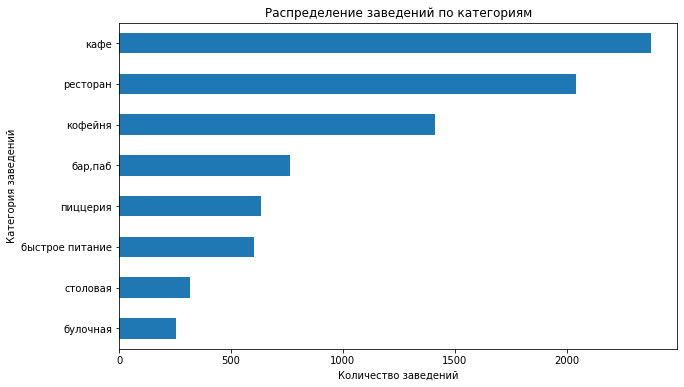

```python
# Создаём контейнер графика matplotlib и задаём его размер
plt.figure(figsize=(10, 6))

# Строим линейчатую диаграмму с помощью pandas через plot(kind='barh')
actual_df['category'].value_counts().sort_values(ascending=True).plot(
    kind='barh',
    x='category',
    y='count',
    legend=False,
    title=f'Распределение заведений по категориям'
)

# Настраиваем оформление графика
plt.xlabel('Количество заведений')
plt.ylabel('Категория заведений')

# Выводим график
plt.show()
```

- Распределение заведений по категориям показывает, что наиболее распространёнными типами заведений в Москве являются:
  - `кафе`: (`28.28%`),
  - `рестораны`: (`24.29%`),
  - `кофейни`: (`16.82%`). Эти три категории составляют почти `70%` всех объектов общественного питания.
- Менее популярны `булочные` и `столовые` — их доля не превышает `4%` каждая.

Такое распределение говорит о высокой концентрации заведений, ориентированных на досуг и встречи (`кафе`, `рестораны`), по сравнению с заведениями более утилитарного типа, таких как `столовые` и `булочные`.

### 3.2 Распределение заведений по районам

Изучим какие административные районы Москвы присутствуют в данных.

- Исследуем распределение количества заведений по административным районам Москвы.
- Отдельно рассмотрим Центральный административном округ Москвы.

Результат сопроводим подходящими визуализациями.

```python
# Группируем данные по категориям заведений
district_grouped = actual_df.groupby('district', as_index=False).agg({
    'name':'count'
})

# Переименуем столбец name в count
district_grouped = district_grouped.rename(columns={'name': 'count'})

# Добавим расчет относительных значений
total_rows = district_grouped['count'].sum()
district_grouped['share'] = round(district_grouped['count']/total_rows*100, 2)

print("Распределение заведений по районам:")
print(district_grouped.sort_values(by='count', ascending=False))
```

```
Распределение заведений по районам:
                                  district  count  share
5       Центральный административный округ   2242  26.68
2          Северный административный округ    898  10.69
8             Южный административный округ    892  10.62
3  Северо-Восточный административный округ    890  10.59
1          Западный административный округ    850  10.12
0         Восточный административный округ    798   9.50
6     Юго-Восточный административный округ    714   8.50
7      Юго-Западный административный округ    709   8.44
4   Северо-Западный административный округ    409   4.87
```

Для визуального анализа распределения также используем столбчатую диаграмму.

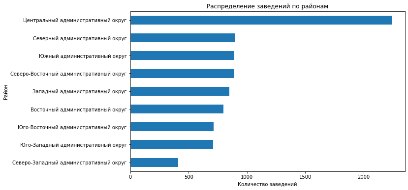

```python
# Создаём контейнер графика matplotlib и задаём его размер
plt.figure(figsize=(10, 6))

# Строим линейчатую диаграмму с помощью pandas через plot(kind='barh')
actual_df['district'].value_counts().sort_values(ascending=True).plot(
    kind='barh',
    x='district',
    y='count',
    legend=False,
    title=f'Распределение заведений по районам'
)

# Настраиваем оформление графика
plt.xlabel('Количество заведений')
plt.ylabel('Район')

# Выводим график
plt.show()
```

Наибольшее число заведений общественного питания сосредоточено в `Центральном административном округе` — `26.68%` от общего количества. Это значительно больше, чем в других районах, что логично — центр города является основным деловым, туристическим и культурным кластером.

Другие округа демонстрируют схожее распределение: доля большинства колеблется в пределах `8–11%`, при этом наименьшая доля у `Северо-Западного округа` — всего `4.87%`. Это может свидетельствовать о меньшей плотности населения, застройки или деловой активности в данном районе.

- Рассмотрим распределение заведений по категориям в Центральном административном округе Москвы.

```python
# Фильтруем данные по Центральному административному округу
central_df = actual_df[actual_df['district'] == 'Центральный административный округ']

# Группируем данные по категориям заведений
central_category_grouped = central_df.groupby('category', as_index=False).agg({
    'name':'count'
})

# Переименуем столбец name в count
central_category_grouped = central_category_grouped.rename(columns={'name': 'count'})

# Добавим расчет относительных значений
total_rows = central_category_grouped['count'].sum()
central_category_grouped['share'] = round(central_category_grouped['count']/total_rows*100, 2)

print("Распределение заведений по категориям в Центральном административном округе Москвы:")
print(central_category_grouped.sort_values(by='count', ascending=False))
```

```
Распределение заведений по категориям в Центральном административном округе Москвы:
          category  count  share
6         ресторан    670  29.88
3             кафе    464  20.70
4          кофейня    428  19.09
0          бар,паб    364  16.24
5         пиццерия    113   5.04
2  быстрое питание     87   3.88
7         столовая     66   2.94
1         булочная     50   2.23
```

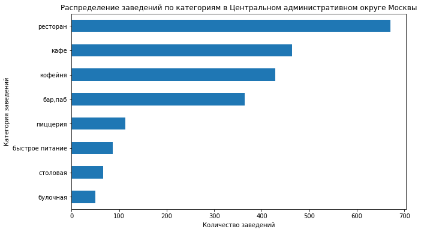

```python
# Создаём контейнер графика matplotlib и задаём его размер
plt.figure(figsize=(10, 6))

# Строим линейчатую диаграмму с помощью pandas через plot(kind='barh')
central_df['category'].value_counts().sort_values(ascending=True).plot(
    kind='barh',
    x='category',
    y='count',
    legend=False,
    title=f'Распределение заведений по категориям в Центральном административном округе Москвы'
)

# Настраиваем оформление графика
plt.xlabel('Количество заведений')
plt.ylabel('Категория заведений')

# Выводим график
plt.show()
```

По результатам анализа распределения заведений по категориям в Центральном административном округе Москвы можно сделать следующие выводы:

- `Рестораны` — наиболее представленная категория, на них приходится почти `30%` всех заведений округа (`670` объектов). Это соответствует статусу округа как делового и туристического центра города.
- `Кафе` (`464 заведения`) и `кофейни` (`428` заведений) также составляют значительную долю — суммарно более `39%`, что свидетельствует о высоком спросе на места для короткого и комфортного отдыха.
- На `бары и пабы` приходится `16.24%` — это довольно высокий показатель, отражающий активную вечернюю и ночную жизнь в округе.
- Остальные категории, такие как `пиццерии`, `быстрое питание`, `столовые` и `булочные`, представлены заметно меньше — каждая занимает менее `6%` от общего числа заведений.

Центральный округ отличается высоким уровнем разнообразия заведений, но при этом делает акцент на форматах с более высоким средним чеком и продолжительным пребыванием — `рестораны`, `кафе` и `кофейни` лидируют с большим отрывом. Это отражает деловой и туристический характер округа.

### 3.3 Сетевые и несетвые заведения

Изучим соотношение сетевых и несетевых заведений в целом по всем данным и в разрезе каждой категории заведений.

- Ответим на следующие вопросы:
  - Каких заведений больше — сетевых или несетевых?
  - Какие категории заведений чаще являются сетевыми?

Изучим первый вопрос: каких заведений больше — сетевых или несетевых?

```python
# Считаем количество сетевых и несетевых заведений
chain_counts = actual_df['chain'].value_counts().rename(index={0: 'Несетевые', 1: 'Сетевые'}).reset_index()
chain_counts.columns = ['chain', 'count']

# Расчёт доли в процентах
total = chain_counts['count'].sum()
chain_counts['share'] = chain_counts['count'] / total * 100

print("Соотношение сетевых и несетевых заведений Москвы:")
print(chain_counts.sort_values(by='count', ascending=False))
```

```
Соотношение сетевых и несетевых заведений Москвы:
       chain  count     share
0  Несетевые   5197  61.85432
1    Сетевые   3205  38.14568
```

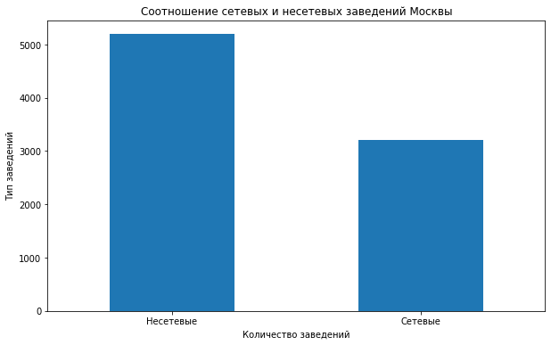

```python
# Создаём контейнер графика matplotlib и задаём его размер
plt.figure(figsize=(10, 6))

# Строим столбчатую диаграмму с помощью pandas через plot(kind='bar')
actual_df['chain'].value_counts().sort_values(ascending=False).rename(index={
    0:'Несетевые',
    1:'Сетевые'}).plot(
        kind='bar',
        y='chain',
        x='count',
        legend=False,
        rot=0,
        title=f'Соотношение сетевых и несетевых заведений Москвы'
    )

# Настраиваем оформление графика
plt.xlabel('Количество заведений')
plt.ylabel('Тип заведений')

# Выводим график
plt.show()
```

- Большая часть заведений общественного питания Москвы — `несетевые` (около `62%`).
- `Сетевые` заведения составляют примерно `38%`.
- Это указывает на то, что независимые заведения доминируют на рынке, однако сети занимают значительную долю, отражая тенденцию к масштабированию и стандартизации в индустрии общественного питания.

Рассмотри второй вопрос: какие категории заведений чаще являются сетевыми?

```python
# Фильтруем данные по отношению к сетевому признаку
chain_df = actual_df[actual_df['chain'] == 1]

# Группируем данные по категориям заведений
chain_category_grouped = chain_df.groupby('category', as_index=False).agg({
    'name':'count'
})

# Переименуем столбец name в count
chain_category_grouped = chain_category_grouped.rename(columns={'name': 'count'})

# Добавим расчет относительных значений
total_rows = chain_category_grouped['count'].sum()
chain_category_grouped['share'] = round(chain_category_grouped['count']/total_rows*100, 2)

print("Распределение сетевых заведений по категориям:")
print(chain_category_grouped.sort_values(by='count', ascending=False))
```

```
Распределение сетевых заведений по категориям:
          category  count  share
3             кафе    779  24.31
6         ресторан    730  22.78
4          кофейня    720  22.46
5         пиццерия    330  10.30
2  быстрое питание    232   7.24
0          бар,паб    169   5.27
1         булочная    157   4.90
7         столовая     88   2.75
```

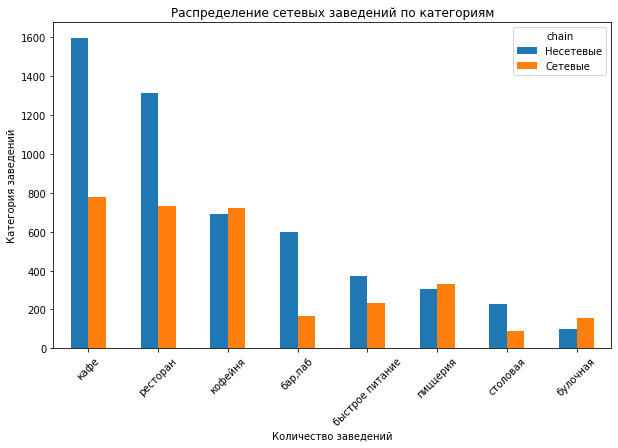

```python
# Группируем по категории и chain
chain_grouped = actual_df.groupby(['category', 'chain'])['id'].count().unstack(fill_value=0)

# Переименовываем столбцы (0 = несетевые, 1 = сетевые) и сортируем по убыванию
chain_grouped = chain_grouped.rename(columns={0: 'Несетевые', 1: 'Сетевые'})
chain_grouped = chain_grouped.sort_values(by=['Несетевые', 'Сетевые'], ascending=False)

# Строим линейчатую диаграмму с помощью pandas через plot(kind='barh')
chain_grouped.plot(
    kind='bar',
    figsize=(10, 6),
    legend=True,
    rot=45
)

# Настраиваем оформление графика
plt.title('Распределение сетевых заведений по категориям')
plt.xlabel('Количество заведений')
plt.ylabel('Категория заведений')

# Выводим график
plt.show()
```

### 3.4 Количество посадочных мест

- Исследуем количество посадочных мест в заведениях:
  - Проанализируем встречаются ли в данных аномальные значения или выбросы. Если да, то с чем они могут быть связаны?
  - Приведем для каждой категории заведений наиболее типичное для него количество посадочных мест.

Познакомимся с `seats` - значения в данном поле относятся к непрерывным вещественным данным. При знакомстве с подобными данными вначале стоит оценить статические показатели. Для этого используем метод `describe()`:

```python
# Изучаем статистические показатели столбца balance
print('Статистические показатели столбца seats:')
df['seats'].describe()
```

```
Статистические показатели столбца seats:
```

```
count    8406.000000
mean       93.786165
std        95.695404
min         0.000000
25%        48.000000
50%        70.000000
75%       100.000000
max      1288.000000
Name: seats, dtype: float64
```

- Среднее значение количества посадочных мест составляет около `94`, а медиана — `70`, что говорит о некотором сдвиге распределения вправо и возможном наличии заведений с большим числом мест.
- Стандартное отклонение довольно велико — около `96`, что свидетельствует о значительном разбросе значений.
- Минимальное значение равно `0`, что, возможно, указывает на пропуски или заведения без фиксированных мест, а максимальное — `1288` — говорит о наличии очень больших заведений.
- Разница между минимальным и максимальным значениями подтверждает наличие выбросов.

Для более детального понимания распределения построим гистограмму и диаграмму размаха по количеству мест.

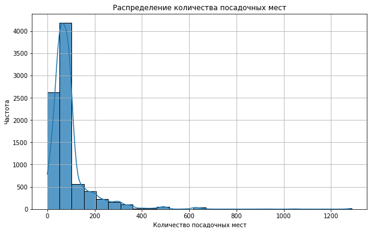

```python
# Создаём контейнер графика matplotlib и задаём его размер
plt.figure(figsize=(10,6))

# Строим гистограмму с помощью pandas через plot(kind='hist')
sns.histplot(data=actual_df,
             x='seats',
             bins=25,
             kde=True,
             alpha=0.75,
             edgecolor='black')

# Настраиваем оформление графика
plt.title('Распределение количества посадочных мест')
plt.xlabel('Количество посадочных мест')
plt.ylabel('Частота')

# Добавляем сетку графика
plt.grid()

# Выводим график
plt.show()
```

- Гистограмма подтверждает правоасимметричное распределение: большинство заведений имеют сравнительно небольшое число посадочных мест (до `200`), при этом распределение сдвинуто вправо с длинным «хвостом», включающим эти выбросы.

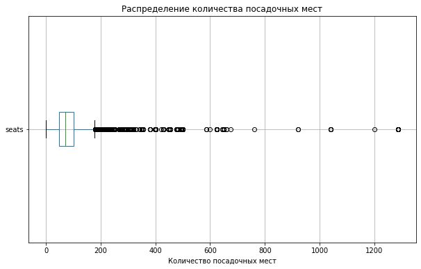

```python
# Создаём контейнер графика matplotlib и задаём его размер
plt.figure(figsize=(10, 6))

# Строим диаграмму размаха значений в столбце balance
actual_df.boxplot(column='seats', vert=False)

# Добавляем заголовок и метки оси
plt.title('Распределение количества посадочных мест')
plt.xlabel('Количество посадочных мест')

# Выводим график
plt.show()
```

Выбросы расположены далеко от «усов» диаграммы, и возникает проблема визуализации основной массы данных. Основные статистические показатели, как медиана или квартили, стали менее заметными на графике. Чтобы решить эту проблему, детализируем масштаб, отключа отображение выбросов на диаграмме

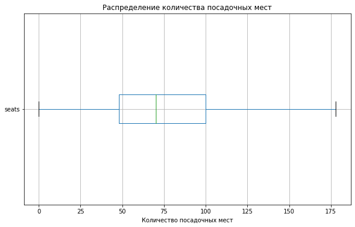

```python
# Создаём контейнер графика matplotlib и задаём его размер
plt.figure(figsize=(10, 6))

# Строим диаграмму размаха значений в столбце balance
actual_df.boxplot(column='seats',
                  vert=False,
                  showfliers=False)

# Добавляем заголовок и метки оси
plt.title('Распределение количества посадочных мест')
plt.xlabel('Количество посадочных мест')

# Выводим график
plt.show()
```

- При анализе распределения количества посадочных мест в заведениях с помощью диаграммы размаха (boxplot) наблюдаются выбросы — значения, существенно превышающие основной диапазон данных. Это указывает на наличие заведений с очень большим количеством посадочных мест, которые могут быть либо крупными банкетными залами, ресторанами с несколькими залами, либо и скорее всего - ошибками в данных.

Отфильтруем нереалистичные значения, больше 99 процентиля.

```python
# Считаем 99-й перцентиль
percentile_99 = actual_df['seats'].quantile(0.99)
print(f"99-й перцентиль: {percentile_99:.2f}")

# Оставляем только реалистичные заведения
filtered_df = actual_df[actual_df['seats'] <= percentile_99]
```

```
99-й перцентиль: 490.90
```

- Мы отфильтровали выбросы, выходящие за пределы 99 процентиля (выше 490.90 мест). Теперь снова пересчитаем описательные стаитистики и построим графики.

```python
# Изучаем статистические показатели столбца balance отфильтрованного датасета
print('Статистические показатели столбца seats:')
filtered_df['seats'].describe()
```

```
Статистические показатели столбца seats:
```

```
count    8317.000000
mean       87.506853
std        68.373216
min         0.000000
25%        48.000000
50%        70.000000
75%        98.000000
max       481.000000
Name: seats, dtype: float64
```

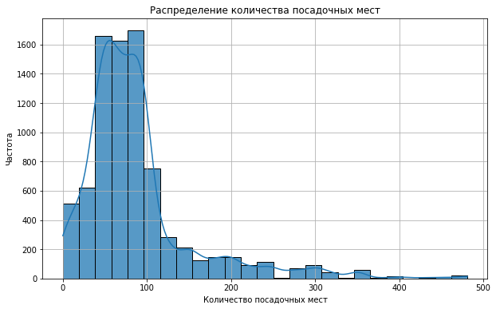

```python
# Создаём контейнер графика matplotlib и задаём его размер
plt.figure(figsize=(10,6))

# Строим гистограмму с помощью pandas через plot(kind='hist')
sns.histplot(data=filtered_df,
             x='seats',
             bins=25,
             kde=True,
             alpha=0.75,
             edgecolor='black')

# Настраиваем оформление графика
plt.title('Распределение количества посадочных мест')
plt.xlabel('Количество посадочных мест')
plt.ylabel('Частота')

# Добавляем сетку графика
plt.grid()

# Выводим график
plt.show()
```

- Очистка данных от выбросов позволила получить более реалистичную картину распределения посадочных мест. Теперь статистики не искажены аномалиями, и мы можем уверенно использовать их для анализа, визуализации и дальнейших выводов.

Рассмотрим распределение количества посадочных мест в рамках каждой категории заведений.

```python
# Группируем по категории и выводим describe для столбца seats
category_stats = filtered_df.groupby('category')['seats'].describe()

# Сортируем по числу записей
category_stats_sorted = category_stats.sort_values(by='count', ascending=False)

# Выводим результат
print(category_stats_sorted)
```

```
                  count        mean        std  min   25%   50%    75%    max
category
кафе             2353.0   75.719932  61.676510  0.0  45.0  60.0   84.0  481.0
ресторан         2014.0  101.889523  70.610909  0.0  60.0  90.0  100.0  481.0
кофейня          1397.0   86.451682  65.109993  0.0  50.0  75.0   96.0  480.0
бар,паб           755.0   99.953642  74.089494  0.0  60.0  90.0   99.0  480.0
пиццерия          629.0   81.390302  72.572777  0.0  40.0  56.0   96.0  455.0
быстрое питание   601.0   85.876040  73.514880  0.0  40.0  69.0  100.0  450.0
столовая          313.0   82.233227  57.903724  0.0  48.0  72.0   95.0  428.0
булочная          255.0   77.007843  71.967963  0.0  35.0  50.0   98.0  478.0
```

- Теперь визуализируем распределение количества посадочных мест по категориям:

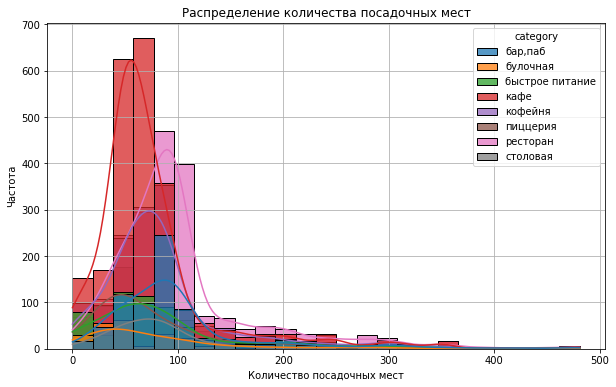

```python
# Создаём контейнер графика matplotlib и задаём его размер
plt.figure(figsize=(10,6))

# Строим гистограмму с помощью pandas через plot(kind='hist')
sns.histplot(data=filtered_df,
             x='seats',
             bins=25,
             kde=True,
             alpha=0.75,
             edgecolor='black',
             hue='category')

# Настраиваем оформление графика
plt.title('Распределение количества посадочных мест')
plt.xlabel('Количество посадочных мест')
plt.ylabel('Частота')

# Добавляем сетку графика
plt.grid()

# Выводим график
plt.show()
```

Приведем для каждой категории заведений наиболее типичное для него количество посадочных мест.

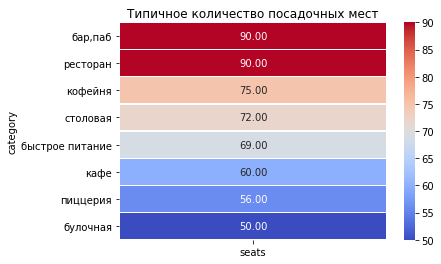

```python
# Посчитаем медиану посадочных места в зависимоcти от типа заведения
filtered_df_agg = filtered_df.groupby(['category'])['seats'].median().to_frame().sort_values(
    by='seats', ascending=False)

# Создаём визуализацию
sns.heatmap(data=filtered_df_agg, annot=True, fmt='.2f', linewidths=0.5, cmap='coolwarm')

# Показываем график с заголовком
plt.title('Типичное количество посадочных мест')
plt.show()
```

Теперь построим боксплот для каждой категории на одном графике.

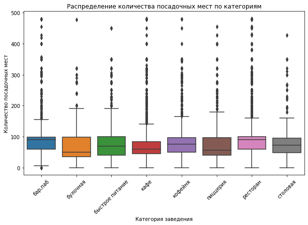

```python
# Создаём контейнер графика matplotlib и задаём его размер
plt.figure(figsize=(10, 6))

# Строим визуализацию
sns.boxplot(data=filtered_df, x='category', y='seats')

# Настраиваем оформление графика
plt.title('Распределение количества посадочных мест по категориям')
plt.xlabel('Категория заведения')
plt.ylabel('Количество посадочных мест')
plt.xticks(rotation=45)

# Выводим график
plt.show()
```

После фильтрации данных по 99-му перцентилю выбросы по-прежнему заметны на боксплотах практически во всех категориях. Это говорит о том, что глобальная фильтрация по общему 99-му перцентилю недостаточна: экстремальные значения могут оставаться внутри категорий, особенно в тех, где распределение сильно асимметрично.

Корректный способ обработки выбросов — использовать межквартильный размах `IQR` по каждой категории на основе датасета `actual_df`:

- Для каждой категории:
  - Вычислим квартили `Q1` и `Q3`;
  - Рассчитаем межквартильный размах: `IQR = Q3 – Q1`.
  - Вычислим верхний порог для выбросов:
    - Верхний порог: `Q3 + 1.5 * IQR`
  - Отфильтруем значения за пределами этих границ для каждой категории индивидуально.

```python
# Создадим пустой датафрейм для результата
filtered_iqr_df = pd.DataFrame()

# Фильтрация по IQR внутри каждой категории
for category, group in actual_df.groupby('category'):
    # Вычисляем квартили и IQR
    Q1 = group['seats'].quantile(0.25)
    Q3 = group['seats'].quantile(0.75)
    IQR = Q3 - Q1
    upper_bound = Q3 + 1.5 * IQR

    # Сохраняем порог в словарь
    filtered_iqr_df[category] = upper_bound

    # Отфильтруем значения за пределами верхнего порога
    filtered_group = group[group['seats'] <= upper_bound]
    filtered_iqr_df = pd.concat([filtered_iqr_df, filtered_group], ignore_index=True)

# Выведем значения верхнего порога и первые пять строк фильтрованного датасета
print(f'Количество строк датафрейма без выбросов: {len(filtered_iqr_df)}')
```

```
Количество строк датафрейма без выбросов: 7403
```

- Рассчитаем количество отфильтрованных строк в абсолютном и относительном значениях

```python
# Посчитаем количество удалённых строк в абсолютном и относительном значениях
deleted_row_cnt = len(actual_df) - len(filtered_iqr_df)
deleted_row_prc = round((1-len(filtered_iqr_df)/len(actual_df))*100, 2)

# Выводим результаты
print(f"Количество строк исходных данных: {len(actual_df)}.")
print(f"Количество строк после подготовки данных: {len(filtered_iqr_df)}.")
print(f"Количество удалённых строк: {deleted_row_cnt}, что составляет {deleted_row_prc}% от исходных данных.")
```

```
Количество строк исходных данных: 8402.
Количество строк после подготовки данных: 7403.
Количество удалённых строк: 999, что составляет 11.89% от исходных данных.
```

- Заново рассмотрим распределение количества посадочных мест в рамках каждой категории заведений отфильтрованного датафрейма.

```python
# Группируем по категории и выводим describe для столбца seats
category_stats = filtered_iqr_df.groupby('category')['seats'].describe()

# Сортируем по числу записей
category_stats_sorted = category_stats.sort_values(by='count', ascending=False)

# Выводим результат
print(category_stats_sorted)
```

```
                  count       mean        std  min   25%   50%     75%    max
category
кафе             2122.0  58.820452  25.890123  0.0  45.0  58.0   70.00  141.0
ресторан         1726.0  78.147451  30.970521  0.0  60.0  80.0  100.00  155.0
кофейня          1260.0  68.842857  32.652324  0.0  49.0  66.0   86.00  165.0
бар,паб           662.0  76.859517  29.548274  0.0  52.5  88.0   94.75  155.0
пиццерия          570.0  62.506140  39.433716  0.0  38.0  50.0   89.00  180.0
быстрое питание   535.0  64.797196  39.734577  0.0  40.0  60.0   86.50  190.0
столовая          294.0  70.517007  31.869503  0.0  48.0  72.0   86.00  160.0
булочная          234.0  59.764957  41.231190  0.0  35.0  50.0   90.00  190.0
```

- Теперь визуализируем распределение количества посадочных мест по категориям и построим групповой боксплот отфильтрованного датафрейма.

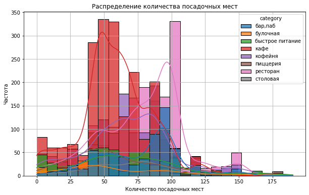

```python
# Создаём контейнер графика matplotlib и задаём его размер
plt.figure(figsize=(10,6))

# Строим гистограмму с помощью pandas через plot(kind='hist')
sns.histplot(data=filtered_iqr_df,
             x='seats',
             bins=25,
             kde=True,
             alpha=0.75,
             edgecolor='black',
             hue='category')

# Настраиваем оформление графика
plt.title('Распределение количества посадочных мест')
plt.xlabel('Количество посадочных мест')
plt.ylabel('Частота')

# Добавляем сетку графика
plt.grid()

# Выводим график
plt.show()
```

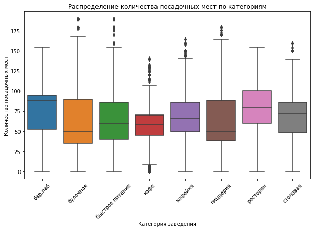

```python
# Создаём контейнер графика matplotlib и задаём его размер
plt.figure(figsize=(10, 6))

# Строим визуализацию
sns.boxplot(data=filtered_iqr_df, x='category', y='seats')

# Настраиваем оформление графика
plt.title('Распределение количества посадочных мест по категориям')
plt.xlabel('Категория заведения')
plt.ylabel('Количество посадочных мест')
plt.xticks(rotation=45)

# Выводим график
plt.show()
```

Выбросы действительно присутствовали почти во всех категориях. Их природа, вероятно, связана c ошибками ввода.

### 3.5 Рейтинг заведений

Исследуем рейтинг заведений. Визуализируем распределение средних рейтингов по категориям заведений. Проанализируем насколько сильно различаются усреднённые рейтинги для разных типов общепита.

- Для начала посчитаем средние рейтинги по категориям.

```python
# Средний рейтинг по каждой категории
avg_ratings = actual_df.groupby('category')['rating'].mean().sort_values(ascending=False)

# Переведем в датафрейм для наглядности
avg_ratings_df = avg_ratings.reset_index()

# Выведем датафрейм
print('Средний рейтинг каждой из категорий:')
print(avg_ratings_df)
```

```
Средний рейтинг каждой из категорий:
          category    rating
0          бар,паб  4.387712
1         пиццерия  4.301264
2         ресторан  4.290348
3          кофейня  4.277282
4         булочная  4.268359
5         столовая  4.211429
6             кафе  4.124285
7  быстрое питание  4.050249
```

- Визуализируем средние рейтинги.

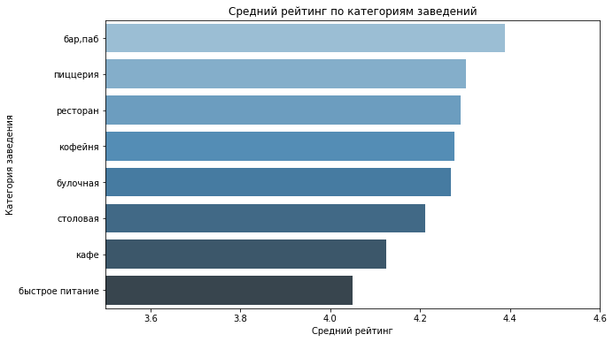

```python
# Определим порядок категорий на основе рейтинга
category_order = avg_ratings_df.sort_values(by='rating', ascending=False)['category']

# Создаём контейнер графика matplotlib и задаём его размер
plt.figure(figsize=(10, 6))

# Cтроим визуализацию
sns.barplot(data=avg_ratings_df,
            x='rating',
            y='category',
            order=category_order,
            palette='Blues_d')

# Настраиваем оформление графика
plt.title('Средний рейтинг по категориям заведений')
plt.xlabel('Средний рейтинг')
plt.ylabel('Категория заведения')
plt.xlim(3.5, 4.6)  # ограничим ось для фокусировки

# Показываем график
plt.show()
```

- Средние рейтинги различных типов заведений находятся в достаточно узком диапазоне — от `4.05` до `4.39`, что указывает на в целом высокую оценку общепита пользователями. Однако, несмотря на это, можно заметить некоторые различия:
  - Наивысший средний рейтинг у категории `бар, паб` — `4.39`, что может говорить о высокой удовлетворённости посетителей атмосферой и сервисом в таких заведениях.
  - `Пиццерии`, `рестораны` и `кофейни` также демонстрируют хорошие оценки — от `4.27` до `4.30`.
  - `Булочные` и `столовые` занимают середину рейтинга.
  - Низшие позиции у `кафе` (`4.12`) и особенно заведений `быстрого питания` — `4.05`, что может быть связано с более низкими ожиданиями от качества обслуживания или продукта.

Хотя разброс рейтингов незначительный, он всё же указывает на то, что формат заведения может влиять на уровень пользовательского удовлетворения.

### 3.6 Корреляции рейтинга заведения с разными данными

Изучим, с какими данными показывают самую сильную корреляцию рейтинги заведений:

- Построем и визуализируем матрицу корреляции рейтинга заведения с разными данными:
  - его категория,
  - положение (административный район Москвы),
  - статус сетевого заведения,
  - количество мест,
  - ценовая категория,
  - признак, является ли заведения круглосуточным.
- Выберем самую сильную связь и проверим ее.

Т.к. нам необходимо оценить связь как между числовыми, так и между категориальными переменными, используем коэффициенте `phi_k` из библиотеки `phik`. Он разработан как обобщение для разных типов данных. Он анализирует, насколько сильно две переменные связаны, независимо от их природы: числовые, категориальные и даже смешанные. Коэффициент поможет определить как линейные, так и нелинейные зависимости, поэтому его можно гибко применять.

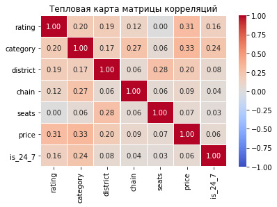

```python
# Выбираем несколько столбцов из датафрейма
corr_columns = [
    'rating',
    'category',
    'district',
    'chain',
    'seats',
    'price',
    'is_24_7'
]

# Вычисляем корреляционную матрицу с использованием phi_k
corr_matrix = actual_df[corr_columns].phik_matrix(interval_cols=['rating', 'seats'])

# Создаём тепловую  карту
sns.heatmap(corr_matrix, annot=True, fmt='.2f', linewidths=0.5, cmap='coolwarm', vmin=-1, vmax=1)

# Показываем график с заголовком
plt.title('Тепловая карта матрицы корреляций')
plt.show()
```

Самая сильная корреляция рейтинга наблюдается с ценовой категорией. Далее проведем дополнительный анализ, чтобы проверить, насколько устойчиво это соотношение. Для начала посчитаем средние рейтинги по ценовым категориям.

```python
# Средний рейтинг по каждой ценовой категории
avg_rating_price = actual_df.groupby('price')['rating'].mean().sort_values(ascending=False)

# Переведем в датафрейм для наглядности
avg_rating_price_df = avg_rating_price.reset_index()

# Выведем датафрейм
print('Средний рейтинг каждой из ценовой категории:')
print(avg_rating_price_df)
```

```
Средний рейтинг каждой из ценовой категории:
           price    rating
0        высокие  4.436611
1  выше среднего  4.386348
2        средние  4.297874
3         низкие  4.173077
4     нет данных  4.166778
```

- Визуализируем средние рейтинги в разрезе ценовой категории.

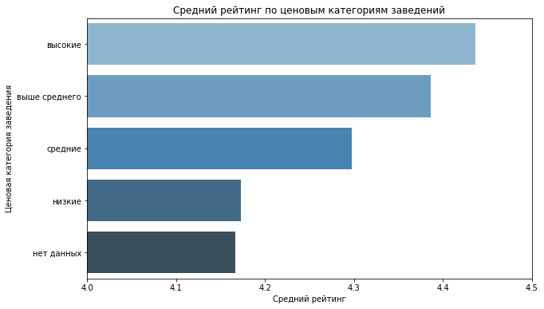

```python
# Определим порядок категорий на основе рейтинга
avg_rating_price_order = avg_rating_price_df.sort_values(by='rating', ascending=False)['price']

# Создаём контейнер графика matplotlib и задаём его размер
plt.figure(figsize=(10, 6))

# Cтроим визуализацию
sns.barplot(data=avg_rating_price_df,
            x='rating',
            y='price',
            order=avg_rating_price_order,
            palette='Blues_d')

# Настраиваем оформление графика
plt.title('Средний рейтинг по ценовым категориям заведений')
plt.xlabel('Средний рейтинг')
plt.ylabel('Ценовая категория заведения')
plt.xlim(4, 4.5)  # ограничим ось для фокусировки

# Показываем график
plt.show()
```

- Заведения с высокими ценами имеют наивысший средний рейтинг — `4.44`.
- Категория `выше среднего` также получила высокую оценку — `4.39`.
- В то время как заведения с низкими ценами имеют наименьший средний рейтинг — `4.17`.

Это может свидетельствовать о том, что более дорогие заведения чаще предлагают лучший сервис, качественную еду и удобства, что отражается в более высоких пользовательских оценках.

Однако различия между категориями не критичны (разброс `~0.26`), поэтому цена — важный, но не единственный фактор, влияющий на рейтинг.

### 3.7 Топ-15 популярных сетей в Москве

- Сгруппируем данные по названиям заведений и найдем топ-15 популярных сетей в Москве.
- Для них посчитаем значения среднего рейтинга. Под популярностью понимается количество заведений этой сети в регионе.
- Проанализируем, к какой категории заведений они относятся.

```python
# Группируем по названию и фильтруем только сетевые заведения
network_counts = actual_df[actual_df['chain'] == 1].groupby('name') \
    .agg({'id': 'count',
          'rating': 'mean'
          }).rename(columns={'id': 'id_count', 'rating': 'avg_rating'})

# Сортируем по количеству филиалов и оставляем топ-15
top_15_networks = network_counts.sort_values(by='id_count', ascending=False).head(15).reset_index()

# Выведем таблицу
print(top_15_networks)
```

```
                                   name  id_count  avg_rating
0                           шоколадница       120    4.177500
1                        домино'с пицца        76    4.169737
2                            додо пицца        74    4.286487
3                      one price coffee        71    4.064789
4                          яндекс лавка        69    3.872464
5                                 cofix        65    4.075385
6                                 prime        50    4.116000
7                            хинкальная        44    4.322727
8                              кофепорт        42    4.147619
9   кулинарная лавка братьев караваевых        39    4.394872
10                              теремок        38    4.123684
11                              чайхана        37    3.924324
12                             cofefest        32    3.984375
13                              буханка        32    4.396875
14                                му-му        27    4.229630
```

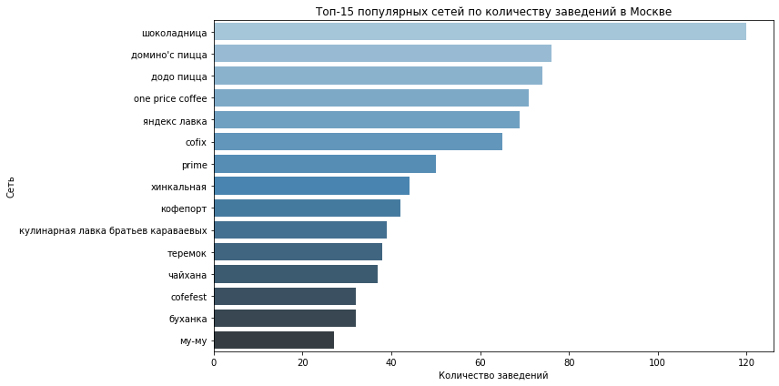

```python
# Создаём контейнер графика matplotlib и задаём его размер
plt.figure(figsize=(12, 6))

# Cтроим визуализацию
sns.barplot(data=top_15_networks,
            y='name',
            x='id_count',
            palette='Blues_d')

# Настраиваем оформление графика
plt.title('Топ-15 популярных сетей по количеству заведений в Москве')
plt.xlabel('Количество заведений')
plt.ylabel('Сеть')
plt.tight_layout()

# Показываем график
plt.show()
```

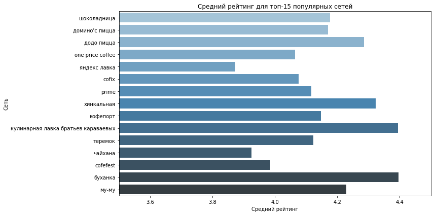

```python
# Создаём контейнер графика matplotlib и задаём его размер
plt.figure(figsize=(12, 6))

# Cтроим визуализацию
sns.barplot(data=top_15_networks,
            y='name',
            x='avg_rating',
            palette='Blues_d')

# Настраиваем оформление графика
plt.title('Средний рейтинг для топ-15 популярных сетей')
plt.xlabel('Средний рейтинг')
plt.ylabel('Сеть')
plt.xlim(3.5, 4.5)
plt.tight_layout()

# Показываем график
plt.show()
```

- В топ-15 самых популярных сетей по количеству заведений в Москве вошли такие бренды, как `Шоколадница` (`120` точек), `Домино’с Пицца` (`76`) и `Додо Пицца` (`74`). Несмотря на высокую представленность, средний рейтинг у лидеров варьируется.
- Наивысший средний рейтинг наблюдается у сети `Буханка` (`4.40`) и `Кулинарная лавка братьев Караваевых` (`4.39`), несмотря на относительно небольшое количество точек (`32` и `39` соответственно).
- Наименьший средний рейтинг — у `Яндекс Лавки` (`3.87`) и `Чайханы` (`3.92`), что может говорить о недостатке качества или завышенных ожиданиях посетителей.
- Большинство сетей из списка относятся к форматам кофеен, пиццерий и заведений быстрого питания, что отражает высокую популярность этих типов заведений у москвичей.

Таким образом, популярность сети (число точек) не всегда совпадает с её рейтингом. Некоторые сети с меньшим числом заведений имеют более высокую оценку, что может свидетельствовать о большем внимании к качеству.

### 3.8 Средний чек

- Изучим вариацию среднего чека заведения (столбец `middle_avg_bill`) в зависимости от района Москвы.
- Проанализируем цены в Центральном административном округе и других.
- Проанализируем, как удалённость от центра влияет на цены в заведениях.

```python
# Средний чек по округам Москвы
avg_bills = actual_df.groupby('district')['middle_avg_bill'].mean()

# Переведем в датафрейм для наглядности
avg_bills_df = avg_bills.sort_values(ascending=False).reset_index()

# Выведем датафрейм
print('Средний чек по округам Москвы:')
print(avg_bills_df)
```

```
Средний чек по округам Москвы:
                                  district  middle_avg_bill
0          Западный административный округ       125.029412
1       Центральный административный округ       106.050847
2             Южный административный округ        95.261211
3   Северо-Западный административный округ        94.244499
4          Северный административный округ        90.545100
5  Северо-Восточный административный округ        86.565169
6      Юго-Западный административный округ        79.006347
7     Юго-Восточный административный округ        70.494398
8         Восточный административный округ        69.475564
```

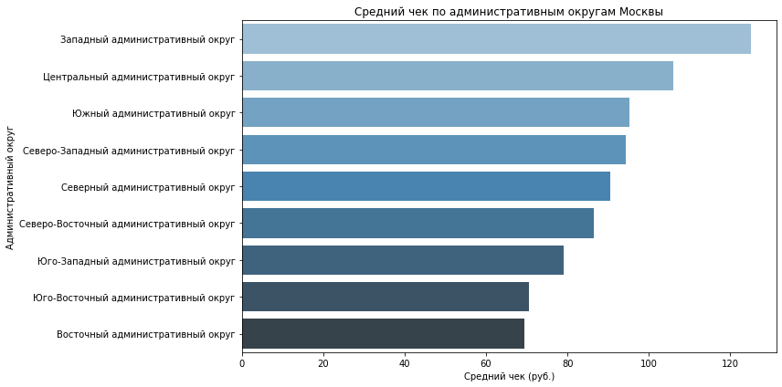

```python
# Определим порядок округов на основе среднего чека
avg_bills_order = avg_bills_df.sort_values(by='middle_avg_bill', ascending=False)['district'].tolist()

# Создаём контейнер графика matplotlib и задаём его размер
plt.figure(figsize=(12, 6))

# Cтроим визуализацию
sns.barplot(data=avg_bills_df,
            y='district',
            x='middle_avg_bill',
            order=avg_bills_order,
            palette='Blues_d')

plt.title('Средний чек по административным округам Москвы')
plt.xlabel('Средний чек (руб.)')
plt.ylabel('Административный округ')
plt.tight_layout()

# Показываем график
plt.show()
```

- Средний чек в заведениях Москвы заметно варьируется в зависимости от административного округа.
  - Максимальные значения среднего чека наблюдаются в `Западном административном округе` (около `125` рублей),
  - `Центральном административном округе` (около `106` рублей). Это может быть связано с более высокой концентрацией дорогих и престижных заведений в этих районах.
- В то же время, самые низкие средние чеки характерны для `Восточного` и `Юго-Восточного административных округов` — около `70` рублей. Вероятно, в этих округах представлены более бюджетные заведения или заведения с меньшим средним чеком.

### 3.9 Промежуточный вывод

Анализ заведений общественного питания Москвы показал, что рынок сильно сегментирован по типам, формату и географии.

- Основные форматы — `кафе`, `рестораны` и `кофейни` — доминируют по количеству (около `70%` от всего рынка), что отражает предпочтения москвичей к досугу и социальным встречам. В `Центральном административном округе`, как деловом и туристическом центре, акцент на `ресторанах`, `каф`е и `кофейнях` особенно заметен, а развитая ночная жизнь выражается в высокой доле `баров и пабов`.
- Сетевой формат развития наиболее популярен именно в `кафе`, `ресторанах` и `кофейнях`, что связано с их востребованностью и проходимостью. При этом популярность сети по количеству точек не всегда совпадает с качеством — некоторые сети с меньшим числом заведений демонстрируют более высокие рейтинги, подчеркивая важность не только масштабов, но и качества обслуживания.
- Анализ вместимости заведений выявил, что `рестораны` и `бары` ориентированы на большие потоки гостей (медиана около `90` посадочных мест), в то время как `кафе`, `кофейни`, `пиццерии` и `булочные` — более компактные форматы с меньшим числом мест, что соответствует их назначению и стилю обслуживания.
- Рейтинги посетителей в целом высоки для всех категорий, но наиболее довольны качеством `баров, пабов` и дорогих заведений. Средний чек коррелирует с районом города: в `Западном` и `Центральном округах` цены выше, что отражает более престижные и дорогие заведения, в то время как в отдалённых районах средний чек существенно ниже. Это демонстрирует значимое влияние географии и экономического уровня районов на ценовую политику.

## 4 Итоговый вывод и рекомендации

По результатам проведённого исследовательского анализа данных сформулируем итоговый вывод и рекомендации для заказчика. Постараемся акцентировать внимание на ключевых моментах исследования.

### 4.1 Общий обзор проделанной работы

В ходе исследования проведён комплексный анализ данных из двух датасетов, содержащих информацию о заведениях общественного питания Москвы: основной — с характеристиками заведений (`8406` записей) и дополнительный — с ценовыми показателями (`4058` записей). Были выполнены этапы предобработки и оптимизации данных, включая работу с пропусками, преобразование типов данных, выявление и удаление дубликатов, а также агрегация по ключевым признакам.

Особое внимание уделялось заполнению пропусков в таких ключевых столбцах, как количество посадочных мест и средний чек, что позволило значительно повысить качество и полноту данных для дальнейшего анализа.

### 4.2 Главные выводы

- Структура рынка общественного питания Москвы:
  - Наиболее распространёнными типами заведений являются `кафе` (`28%`), `рестораны` (`24%`) и `кофейни` (`17%`), вместе они составляют почти `70%` от общего числа. Менее представлены булочные и столовые. В Центральном округе преобладают `рестораны` и `кафе`, что отражает деловой и туристический характер района.
- Сетевые заведения:
  - Сетевой формат наиболее развит в категориях `кафе`, `ресторанов` и `кофеен`, составляющих почти `70%` всех сетевых точек. Менее распространены сети в сегментах `быстрого питания`, `пиццерий` и `баров`.
- Размер заведений (посадочные места):
  - Средний размер заведений варьируется от `50` до `90` мест в зависимости от категории. `Рестораны` и `бары/пабы` — наиболее вместительные, `булочные` и `пиццерии` — самые компактные. Заполнение пропусков по количеству мест позволило получить более репрезентативную картину.
- Рейтинги и качество:
  - Все категории заведений получили высокие оценки пользователей (от `4.05` до `4.39`), при этом `бары и пабы` имеют самый высокий средний рейтинг. Более дорогие заведения традиционно имеют более высокие оценки, что говорит о зависимости качества сервиса и восприятия от ценового сегмента.
- Ценовые особенности:
  - Средний чек существенно различается по округам: в `центральных` и `западных округах` он выше (около `106-125` рублей), в `восточных` и `юго-восточных` — ниже (около `70` рублей). Высокий процент заполненности ценовых данных в дорогих заведениях говорит о более структурированном подходе к информированию клиентов.

### 4.3 Рекомендации на основе анализа данных

**Ценовая политика**

- Учитывая, что в дорогих заведениях чаще и точнее указываются средние чеки, а у недорогих — много пропусков и неопределённостей, рекомендуется:
  - В премиум и среднем сегментах акцентировать внимание на прозрачности и структуре меню с чётким указанием цен.
  - В доступных форматах возможны более гибкие ценовые предложения, акцент на акции и форматы навынос.

**Сетевой формат**

- При открытии заведения в сетевом формате нужно уделить особое внимание контролю качества и единству стандартов, поскольку сеть не всегда гарантирует высокий рейтинг.